# Автоматическое определение языка

# для языков с идентичными алфавитами

#### Титков Даниил

#### 10.12.17

#### МКЛ171

## Введение

Судя по информации об алфавитах языков, приведенной в [статье](https://en.wikipedia.org/wiki/Wikipedia:Language_recognition_chart) Википедии, языков, алфавиты которых полностью идентичны, совсем немного. Даже те языки, которые пользуются одной системой письменности, например, латиницей, как правило, имеют уникальных набор букв с диакритиками. Из этого следует, что для таких языков задача определения языка сильно упрощается и сводится к поиску характерных символов.

Более интересной представляется задача определения языка в том случае, когда алфавит (с учетом диакритических знаков) не может быть различительным признаком. В таком случае, видимо, в качестве признаков будут выступать характерные буквосочетания, высокочастотные морфемы, служебные слова.

```python
import re
import wikipedia as wk
import pandas as pd
import numpy as np
from wikipedia import DisambiguationError, PageError
from tqdm import tqdm # progress-bar
import seaborn as sns
from sklearn.feature_extraction.text import CountVectorizer
from sklearn.ensemble import RandomForestClassifier
from sklearn.naive_bayes import MultinomialNB
from sklearn.linear_model import LogisticRegression
from sklearn.svm import LinearSVC
from sklearn import metrics
from sklearn.model_selection import train_test_split
import matplotlib.pyplot as plt
from unidecode import unidecode

from jupyterthemes import jtplot #внешний вид ноутбука и графиков
jtplot.style(theme='grade3')
%matplotlib inline
```

## Получение данных

Определим функцию для скачивания случайных статей из Википедии для заданного языка. Для обращения к Википедии используем библиотеку **wikipedia**. Также определим функцию для очистки текстов от небуквенных символов

```python
def cleanse(s, rgxp = '[\W\d]'):
    return re.sub(' +', ' ', re.sub(rgxp, ' ', s.lower()))
```

```python
def get_random_pages(langs, n):
    dropped = 0
    articles = {'lang':[], 'content':[], 'url':[], 'title':[]}
    for lang in langs:
        wk.set_lang(lang)
        for i in tqdm(range(n), desc=lang):
            try:
                article = wk.page(wk.random(pages=1))
                articles['content'].append(article.content)
                articles['lang'].append(lang)
                articles['url'].append(article.url)
                articles['title'].append(article.title)
            except (DisambiguationError, PageError) as error:
                dropped += 1
                continue
    print('{:.2%} запросов пропущено'.format(dropped/(len(langs)*n)))
    return articles
```

На основании данной статьи https://en.wikipedia.org/wiki/Wikipedia:Language_recognition_chart выберем языки с одинаковыми алфавитами. К сожалению, языков, алфавиты которых полностью идентичны, совсем немного. В частности, для латиницы это английский, латинский, малайский, зулу и суалихи. При этом статей на зулу и суахили в Википедии совсем мало, и многие из них пустые, так что нет смысла использовать эти языки. В качестве альтернативы можно использовать языки, которые отличаются от других только диакритиками и т.д., предварительно преобразовав буквы с диакритиками в обычные буквы. Для интереса возьмем в том числе испанский и португальский языки, которые очень похожи.

```python
langs = sorted(['en', 'la', 'ms', 'pt', 'es', 'fr'])
n = 300
print('{} языков, по {} статей. Примерное время скачивания - {:.2} минут'
      .format(len(langs), n, n*len(langs)*2.5/60))
```

```
6 языков, по 300 статей. Примерное время скачивания - 7.5e+01 минут
```

Проверим, что алфавиты в выбранных языках действительно одинаковые. Вопользуемся библиотекой **unidecode**, чтобы избавиться от букв с диакритиками и символов IPA, которые могут встречаться в статьях.

```python
def get_alphabet(text):
    chars = []
    for char in cleanse(text, rgxp='[\W\d\s]'):
        chars += char.replace(' ','')
    return ''.join(sorted(set(chars)))
```

```python
examples = []
for lang in tqdm(langs):
    wk.set_lang(lang)
    examples.append(wk.page("Wikipedia").content)
```

```python
alphabets = []
for text in examples:
    alphabets.append(get_alphabet(unidecode(text)))
```

```python
alp = list(zip(langs, alphabets))
print((' '*3), (' '*5).join(langs))
for i in alp:
    l = [str(i[1] == b[1])+'  ' if (i[1] == b[1]) else str(i[1] == b[1])+' ' for b in alp]
    print('{}  {}'.format(i[0][:2], ' '.join(l)))
```

```
    en     es     fr     la     ms     pt
en  True   True   True   True   True   True
es  True   True   True   True   True   True
fr  True   True   True   True   True   True
la  True   True   True   True   True   True
ms  True   True   True   True   True   True
pt  True   True   True   True   True   True
```

Видим, что (с некоторыми принятыми допущениями) алфавиты выбранных языков одинаковы. Скачаем и сохраним статьи (названия, тексты и url) в файл, так как процесс скачивания занимает много времени.

```python
%%time
try:
    data_raw = pd.read_csv('data_raw.csv').drop(['Unnamed: 0'], axis=1)
except FileNotFoundError:
    pd.DataFrame.from_dict(get_random_pages(langs=langs, n=n)).to_csv('data_raw.csv',encoding='utf=8')
    data_raw = pd.read_csv('data_raw.csv').drop(['Unnamed: 0'], axis=1)
```

```
Wall time: 80.2 ms
```

```python
data_raw.shape
```

```
(1729, 4)
```

```python
data_raw.head(3)
```

|  | content | lang | title | url |
| --- | --- | --- | --- | --- |
| 0 | James Masterson (September 18, 1855 – March 31... | en | James Masterson | https://en.wikipedia.org/wiki/James_Masterson |
| 1 | John Osterlind (born 10 March 1967) is an Amer... | en | John Osterlind | https://en.wikipedia.org/wiki/John_Osterlind |
| 2 | Klax is a 1989 puzzle video game designed by D... | en | Klax (video game) | https://en.wikipedia.org/wiki/Klax_(video_game) |

```python
data_raw.tail(3)
```

|  | content | lang | title | url |
| --- | --- | --- | --- | --- |
| 1726 | 2000 SW87 (asteroide 34455) é um asteroide da ... | pt | 34455 2000 SW87 | https://pt.wikipedia.org/wiki/34455_2000_SW87 |
| 1727 | Nicolás Gabriel Albarracín Basil (Montevidéu, ... | pt | Nicolás Albarracín | https://pt.wikipedia.org/wiki/Nicol%C3%A1s_Alb... |
| 1728 | The Un-Americans (originalmente conhecidos com... | pt | The Un-Americans | https://pt.wikipedia.org/wiki/The_Un-Americans |

```python
data_raw.groupby('lang').count()
```

| lang | content | title | url |
| --- | --- | --- | --- |
| en | 284 | 284 | 284 |
| es | 284 | 284 | 284 |
| fr | 281 | 281 | 281 |
| la | 295 | 295 | 295 |
| ms | 297 | 297 | 297 |
| pt | 288 | 288 | 288 |

Некоторые статьи могут быть пустыми, удалим их

```python
data_raw.dropna(how='any', inplace=True)
```

## Предобработка

С помощью ранее определенной функции **cleanse** очистим тексты от небуквенных символов. Так как в дальнейшем предполагается работать с буквенными н-граммами, а окончания могут быть характерными признаками языка, лемматизация или стемминг не используется. Также избавимся от unicode-символов с помощью **unidecode**.

```python
%%time
data = data_raw.copy()
tqdm.pandas(desc="Cleanse")
data.content = data.content.progress_apply(cleanse)
tqdm.pandas(desc="Unidecode")
data.content = data.content.progress_apply(unidecode)
```

```
Wall time: 3.06 s
```

Посмотрим на получившийся результат

```python
data.content[1][:500]
```

```
'john osterlind born march is an american radio broadcaster osterlind was born in norwalk connecticut he graduated from roger ludlowe high school in fairfield connecticut in and from dean jr college in franklin massachusetts in where he was on their college station fm wgao he was on air overnights o…
```

```python
data.content[550][:500]
```

```
'ras kass nacido como john austin el de septiembre de en watts california es un rapero norteamericano sus fans alaban su destreza tecnica como mc y tanto la pasion por la musica y su actitud comprometida queda patente en su contenido lirico carrera ras kass debuto con soul on ice en el album desarro…
```

Случайным образом разделим набор данных на обучающую и текстовую подвыборки.

```python
text_train, text_test, lang_train, lang_test = train_test_split(data.content,
                                                                data.lang,
                                                                test_size=0.33,
                                                                random_state=1)
```

```python
print('Обучающая выборка: {} текстов'.format(len(text_train)))
text_train.head(3)
```

```
Обучающая выборка: 1158 текстов
```

```
1617    dourados esporte clube foi um clube brasileiro...
1177    buhl lorraine ialah komun di jabatan moselle d...
239     new woodville is a town in marshall county okl...
Name: content, dtype: object
```

```python
print('Тестовая выборка: {} текстов'.format(len(text_test)))
text_test.head(3)
```

```
Тестовая выборка: 571 текстов
```

```
1233    campodolcino merupakan sebuah komune yang terl...
592     sainte colombe de villeneuve est une commune d...
625     ermentar de noirmoutier egalement appele ermen...
Name: content, dtype: object
```

## Векторизация текстов

Для того, чтобы к текстам можно было применять алгоритмы машинного обучения, они должны быть представлены в виде числовых векторов. Для преобразования текстов в векторы используем **CountVectorizer** из пакета **sklearn**. В результате этого получим матрицу тексты*признаки, где признаки - триграммы, а в ячейках матрицы - количество вхождений данной триграммы в данный текст. Для векторайзера зададим параметр min_df, чтобы не учитывать триграммы, которые встречаются лишь в единичных текстах.

```python
vectorizer = CountVectorizer(ngram_range=(3,3),
                             lowercase=True,
                             analyzer = 'char',
                             min_df = 10,
                             max_df = 1.0)
```

```python
%%time
data_train = vectorizer.fit_transform(text_train)
data_test = vectorizer.transform(text_test)
```

```
Wall time: 2.31 s
```

```python
print('{} наблюдений, {} признаков'.format(data_train.shape[0], data_train.shape[1]))
```

```
1158 наблюдений, 4815 признаков
```

Посмотрим, какие триграммы сохранены векторайзером (выведем 20 случайных).

```python
print('Всего вошло триграмм:', data_train.shape[1])
np.array(vectorizer.get_feature_names()
)[np.random.randint(0, len(vectorizer.get_feature_names()), 20)]
```

```
Всего вошло триграмм: 4815
```

```
array(['kej', 'x d', 'arg', 'e g', 'muy', 'hug', 'eyo', 'twi', 'sbu',
       'adj', 'ai ', 'ncl', 'ell', 'yam', 'b o', 'adj', 'ujo', 'lot',
       'ksi', 'keb'],
      dtype='<U3')
```

Также посмотрим на 20 случайных триграмм из списка исключенных в силу низкой частотности.

```python
print('Всего исключенных триграмм:', len(vectorizer.stop_words_))
np.array(list(vectorizer.stop_words_))[np.random.randint(0, len(vectorizer.stop_words_), 20)]
```

```
Всего исключенных триграмм: 4488
```

```
array(['ewr', 'bmi', 'myl', 'eeb', 'mtv', 'dgr', 'cnr', 'zag', 'igs',
       'gyp', 'jux', 'xak', 'dgm', 'euh', 'zov', 'uaq', 'ayt', 'caj',
       'md ', 'atq'],
      dtype='<U3')
```

## Baseline decision

В качестве базового классификатора будет использоваться логистическая регрессия, так как этот метод быстро работает и прост в интерпретации. Перед началом работы определим функцию для удобного вывода метрик для оценки качества классификации.

```python
def evaluate(y_true, y_pred):
    print("Accuracy: {}".format(metrics.accuracy_score(y_true, y_pred)))
    print(metrics.classification_report(y_true, y_pred))
```

```python
%%time
logreg = LogisticRegression(multi_class='multinomial', solver='saga')
logreg = LogisticRegression()
logreg.fit(data_train, lang_train)
```

```
Wall time: 2.23 s
```

```python
print('Train:')
train_pred = logreg.predict(data_train)
evaluate(lang_train, train_pred)

print('Test:')
test_pred = logreg.predict(data_test)
evaluate(lang_test, test_pred)
```

```
Train:
Accuracy: 1.0
             precision    recall  f1-score   support

         en       1.00      1.00      1.00       195
         es       1.00      1.00      1.00       191
         fr       1.00      1.00      1.00       179
         la       1.00      1.00      1.00       203
         ms       1.00      1.00      1.00       196
         pt       1.00      1.00      1.00       194

avg / total       1.00      1.00      1.00      1158

Test:
Accuracy: 0.9912434325744308
             precision    recall  f1-score   support

         en       0.99      0.98      0.98        89
         es       0.99      0.99      0.99        93
         fr       0.98      1.00      0.99       102
         la       0.99      1.00      0.99        92
         ms       1.00      1.00      1.00       101
         pt       1.00      0.98      0.99        94

avg / total       0.99      0.99      0.99       571
```

Классификатор почти не делает ошибок даже на тестовой выборке, а на обучающей точность и полнота составляют 100% для всех языков. Что посмотреть, какими были немногочисленные ошибки в классификации, построим матрицу ошибок.

```python
mat = metrics.confusion_matrix(lang_test, test_pred) # [5]
correct = mat.diagonal().sum()
print('{} текстов ({:.2%}) классифицировано правильно'.format(correct, correct/len(lang_test)))
```

```
566 текстов (99.12%) классифицировано правильно
```

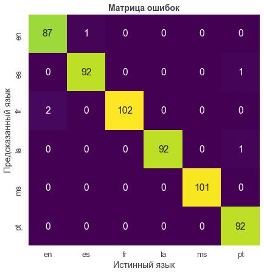

```python
sns.set_context("talk")
plt.figure(figsize=(7,7))
sns.heatmap(mat.T, square=True, annot=True, fmt='d', cbar=False,
            cmap='viridis',
            xticklabels=sorted(langs),
            yticklabels=sorted(langs))
plt.xlabel('Истинный язык')
plt.ylabel('Предсказанный язык')
plt.title(('Матрица ошибок'), fontsize=14, fontweight='bold');
```

Видим, что качество классификации очень высоко, когда мы используем полные тексты статей из тестовой выборки. Число ошибок слишком невелико, чтобы определить, есть ли в них какая-то закономерность. Можно лишь отметить, что испанский и португальский язык хорошо отделяются друг от друга. Причиной ошибок может быть включение в статьи фрагментов (в том числе крупных) на других языках.

Посмотрим, какие признаки (н-граммы) оказались наиболее значимыми для каждого языка. Выведем список предикторов с наибольшими коэффициентами для всех языков.

```python
n = 6
for lang in langs:
    i = langs.index(lang)
    print('For "{}"'.format(lang))
    for y in sorted(list(zip(logreg.coef_[i], vectorizer.get_feature_names())), reverse=True)[0:n]:
        print('{}   {:.2}'.format(y[1], y[0]))
    print()
```

```
For "en"
 is   0.34
he    0.34
s a   0.3
 a    0.29
of    0.27
the   0.27

For "es"
 en   0.44
el    0.3
on    0.29
cio   0.26
 el   0.26
s u   0.25

For "fr"
il    0.3
tai   0.26
e d   0.23
ail   0.23
ort   0.23
le    0.22

For "la"
us    0.47
ae    0.39
um    0.24
tur   0.18
st    0.17
rae   0.17

For "ms"
an    0.45
ah    0.36
di    0.27
 se   0.26
 di   0.22
kan   0.2

For "pt"
 e    0.61
 um   0.51
e u   0.37
da    0.33
ao    0.33
o d   0.33
```

Глядя на полученные результаты для, например, английского языка, можно сразу узнать одни из самых распространенных слов этого языка - *the*, *he*, *is*. Триграмма *s_a*, видимо, обнаруживается, когда за глаголом в третьем лице следует существительное с неопределенным артиклем (например, как в *she take**s a** cup*).

Для латыни, судя по всему, наиболее значимыми предикторами оказались характерные окончания слов: *us*, *ae*, *um*. Для португальского - союз *e* и некоторые артикли.

Для содержательной интерпретации результатов по другим языкам мне не хватает знания этих языков, но представляется, что полученные результаты можно обобщить следующим образом: в ситуации полной идентичности алфавитов, самыми сильными признаками для определения языка выступают, в первую очередь, те элементы текстов, которые относятся к грамматике - характерные аффиксы, союзы, предлоги, артикли.

## Длина текстов

Следующий вопрос - насколько длинным должен быть текст для определения языка? Сколько букв достаточно? Расчитаем метрики для текстов разной длины.

```python
%%time
%%capture
f1, recall, prec = [], [], []
lens = list(range(2, 350))
for i in lens:
    text_trunc, data_trunc = [], []
    text_trunc = [x[:i] for x in text_test]
    data_trunc = vectorizer.transform(text_trunc)
    f1.append(metrics.f1_score(lang_test, logreg.predict(data_trunc), average='macro'))
    recall.append(metrics.recall_score(lang_test, logreg.predict(data_trunc), average='macro'))
    prec.append(metrics.precision_score(lang_test, logreg.predict(data_trunc), average='macro'))
```

```
Wall time: 30 s
```

Построим график зависимости точности, полноты и F-меры от количества символов в стимуле

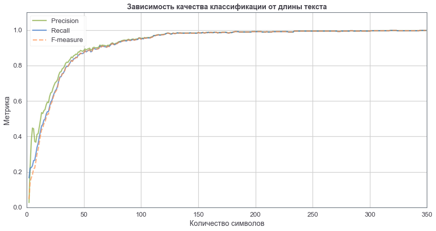

```python
plt.figure(figsize=(14,7))
plt.plot(lens, prec, 'g-', label='Precision', alpha=0.7)
plt.plot(lens, recall, 'b-', label='Recall', alpha=0.7)
plt.plot(lens, f1, 'y--', label='F-measure', alpha=0.7)
plt.xlabel('Количество символов')
plt.ylabel('Метрика')
plt.xlim(0, 350)
plt.ylim(0, 1.1)
plt.title(('Зависимость качества классификации от длины текста'), fontsize=14, fontweight='bold')
plt.legend()
plt.show();
```

Из графика видно, что начиная от приблизительно 200 символов точность стремится к 100%.

## Разные языки

Расчитаем F-меру для каждого языка отдельно при распознавании языка последовательностей разной длины и построим соответствующий график

```python
%%time
%%capture
f1_langs = []
lens = list(range(2, 350))
for i in lens:
    text_trunc, data_trunc = [], []
    text_trunc = [x[:i] for x in text_test]
    data_trunc = vectorizer.transform(text_trunc)
    f1_langs.append(metrics.f1_score(lang_test, logreg.predict(data_trunc), average=None))
```

```
Wall time: 27.8 s
```

```python
f1_res = {}
for lang in langs:
    f1_res[lang] = []
    for i in f1_langs:
        f1_res[lang].append(i[langs.index(lang)])
```

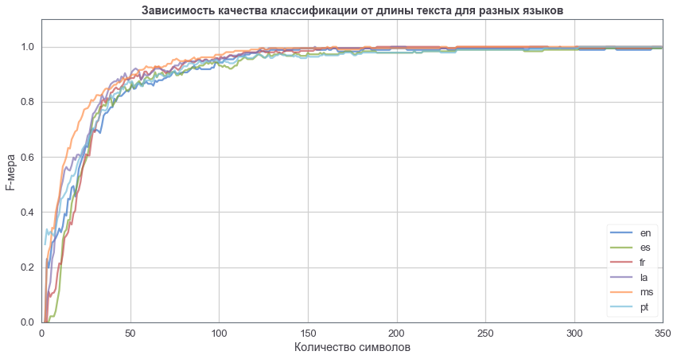

```python
plt.figure(figsize=(14,7))
plt.xlabel('Количество символов')
plt.ylabel('F-мера')
plt.xlim(0, 350)
plt.ylim(0, 1.1)

for lang in langs:
    plt.plot(lens, f1_res[lang], label=lang, alpha=0.7)

plt.title(('Зависимость качества классификации от длины текста для разных языков'),
          fontsize=14, fontweight='bold')
plt.legend()
plt.show();
```

Из графика видно, что лучше всего распознается малайский язык, что можно счесть знакомерным, так как это единственный неевропейский язык в выборке. Несколько хуже распознаются, как и ожидалось, испанский и португальский языки, очень похожие между собой.

## Разные длины н-грамм

Базовое решение было основано на триграммах. Теперь посмотрим, как повлияет на точность определения языка изменение длины н-грамм.

```python
%%time
ns = [1, 2, 3, 4, 5, 6, 7]
lens = list(range(2, 900))

f1_res = {}
for n in tqdm(ns):
    vectorizer_n = CountVectorizer(ngram_range=(n,n),
                             lowercase=True,
                             analyzer = 'char',
                             min_df = 10,
                             max_df = 1.0)
    data_train_ = vectorizer_n.fit_transform(text_train)
    logreg.fit(data_train_, lang_train)
    f1_res[n] = []
    for i in lens:
        text_trunc, data_trunc = [], []
        text_trunc = [x[:i] for x in text_test]
        data_trunc = vectorizer_n.transform(text_trunc)
        f1_res[n].append(metrics.f1_score(lang_test, logreg.predict(data_trunc), average='macro'))
```

```
  'precision', 'predicted', average, warn_for)
```

```
Wall time: 18min 26s
```

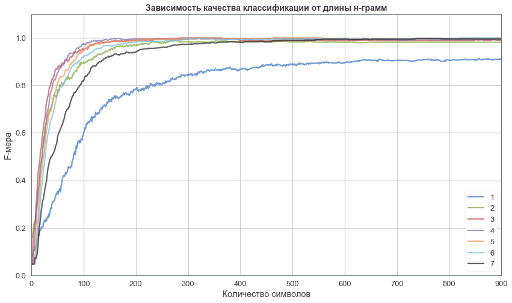

```python
plt.figure(figsize=(14,8))
plt.xlabel('Количество символов')
plt.ylabel('F-мера')
plt.xlim(0, 900)
plt.ylim(0, 1.1)

for n in ns:
    plt.plot(lens, f1_res[n], label=n, alpha=0.7)

plt.title(('Зависимость качества классификации от длины н-грамм'),
          fontsize=14, fontweight='bold')
plt.legend()
plt.show();
```

```python
max(f1_res[1])
```

```
0.91247681117492696
```

Видим, что классификаторы, построенные на 3-, 4- и 5-граммах достигают максимальной точности определения языка при примерно одинаковой длине тектов, тогда как классификатор на биграммах достигает такой точности гораздо позже, а для классификатора на униграммах максимальное качество классификации составляет *F=0,91*. При этом видим, что дальнейшее увеличение окна не ведет к улучшению качества классификации, а использование н-грамм с большим n наоборот снижает его.

## Обучающее множество разного размера

Проверим, какого объема обучающей выборки достаточно для обучения модели, способной классифицировать тексты с высокой точностью.

```python
%%time

ss = [0.01, 0.025, 0.05, 0.1, 0.2, 0.3, 0.4]
lens = list(range(2, 900))
vectorizer_s = CountVectorizer(ngram_range=(3,3),
                             lowercase=True,
                             analyzer = 'char',
                             min_df = 10,
                             max_df = 1.0)

f1_res = {}
for s in tqdm(ss):
    text_train_, text_test_, lang_train_, lang_test_ = train_test_split(data.content,
                                                                data.lang,
                                                                test_size=(1-s),
                                                                random_state=1)
    data_train_ = vectorizer_s.fit_transform(text_train_)
    logreg.fit(data_train_, lang_train_)
    f1_res[s] = []
    for i in lens:
        text_trunc, data_trunc = [], []
        text_trunc = [x[:i] for x in text_test_]
        data_trunc = vectorizer_s.transform(text_trunc)
        f1_res[s].append(metrics.f1_score(lang_test_, logreg.predict(data_trunc), average='macro'))
```

```
  'precision', 'predicted', average, warn_for)
```

```
Wall time: 41min 27s
```

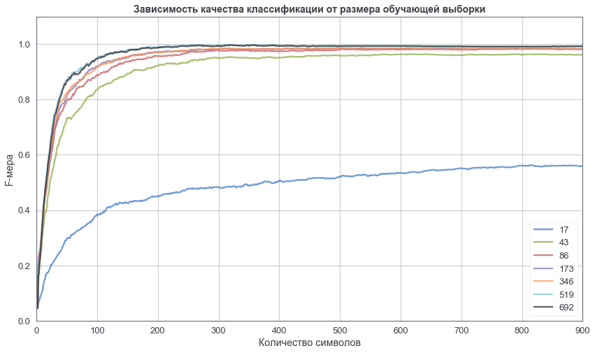

```python
plt.figure(figsize=(14,8))
plt.xlabel('Количество символов')
plt.ylabel('F-мера')
plt.xlim(0, 900)
plt.ylim(0, 1.1)

for s in ss:
    plt.plot(lens, f1_res[s], label=round(len(data.lang)*s), alpha=0.7)

plt.title(('Зависимость качества классификации от размера обучающей выборки'),
          fontsize=14, fontweight='bold')
plt.legend()
plt.show();
```

Судя по полученному графику, исходная обучающая выборка, в которую вошли 1158 текстов, может считаться даже избыточной, так как уже при переходе от 519 текстов к 692 точность распознавания языка не повышается. Кроме того, значительно хуже работает только модель, обученная на 17 текстах, тогда как модель, обученная на 43 текстах дает результат, близкий к максимальному.

## Разные классификаторы

Наконец, сравним различные методы классификации, а именно следующие: логистическая регрессия (для нескольких классов), метод опорных векторов, наивный байесовский классификатор и случайный лес.

```python
mnb = MultinomialNB()
forest = RandomForestClassifier(n_estimators = 100)
svc = LinearSVC()
```

```python
%%time
%%capture
estimators = {'LogisticRegression': logreg,
              'MultinomialNB': mnb,
              'RandomForest': forest,
              'LinearSVC': svc}
lens = list(range(2, 500))

f1_res = {}
for k, v in tqdm(estimators.items()):
    v.fit(data_train, lang_train)
    f1_res[k] = []
    for i in lens:
        text_trunc, data_trunc = [], []
        text_trunc = [x[:i] for x in text_test]
        data_trunc = vectorizer.transform(text_trunc)
        f1_res[k].append(metrics.f1_score(lang_test, v.predict(data_trunc), average='macro'))
```

```
Wall time: 5min 50s
```

[figure not shown]

```python
plt.figure(figsize=(14,8))
plt.xlabel('Количество символов')
plt.ylabel('F-мера')
plt.xlim(0, 500)
plt.ylim(0, 1.1)

for k, v in estimators.items():
    plt.plot(lens, f1_res[k], label=k, alpha=0.7)

plt.title(('Зависимость качества классификации от классификатора'),
          fontsize=14, fontweight='bold')
plt.legend()
plt.show();
```

Из графика видно, что результаты полученные с помощью логистической регрессии, метода опорных векторов и байесовского классификатора, в целом сходны (с небольшим преимуществом байесовского классификатора), тогда как случайный лес на коротких фрагментах текстов работает значительно хуже. При увеличении длинны фрагментов все классификаторы дают одинаково точный результат.